# Social Sciences CoP Presentation

9/2/2020

## Purpose

Review a methodology for personality scale development and showcase features of R statistical program language and R Markdown.

This session follows the “IPIP Scale Construction Procedures” available at: https://ipip.ori.org/newScaleConstruction.htm .

Hypothesis to test during this Session: The Social Science “fit” of members of this CoP is similar to those performing other roles for Northrop Grumman.

## Personality Assessment Design

This 75 question personality assessment you completed aims to measure 15 underlying personality traits using similar measurements to the [Jackson Personality Inventory - Revised (JPI-R)](https://w8y7a2j5.stackpathcdn.com/wp-content/uploads/2015/03/JPI-R-Scales.pdf).

This *JPI-R proxy* consists of questions drawn from the public domain repository of personality questions (https://ipip.ori.org/).

## JPI-R Personality Dimensions

*Analytical Scales*

- Complexity
- Breadth of Interest
- Innovation
- Tolerance

*Extroverted Scales*

- Sociability
- Social Confidence
- Energy Level

*Emotional*

- Empathy
- Anxiety
- Cooperativeness

*Opportunistic*

- Risk Taking
- Social Astuteness

*Dependable*

- Organization
- Traditional Values
- Responsibility

## Scale Construction (1 of 2)

1. Correlate IPIP items (3,000) to 15 JPI-R dimensions and rank order IPIP items based on correlations. https://ipip.ori.org/
2. Inspect the highest positively correlated items for: alignment to intent of the JPI-R measurement and redundancy to other top questions
3. Select the best five questions that tell a coherent story and perform reliability analysis of the items (confirmatory factor analysis using lavaan package in R)
4. Repeat question selection until achievement of a good fit model (TLI > 0.9)

*Data from ~400 individuals, JPI-R raw scores and IPIP question responses, are available in the Eugene-Springfield dataset. https://dataverse.harvard.edu/dataverse/ESCS-Data.

## Scale Construction (2 of 2)

- P_EM1 Am passionate about bettering the world’s condition
- P_EM2 Often do nice things for people
- P_EM3 Know how to comfort others
- P_EM4 Am sensitive to the needs of others
- P_EM5 Am deeply moved by others’ misfortunes

*Innovation Items*

- P_IN1 Come up with bold plans
- P_IN2 Am full of ideas
- P_IN3 Am an original thinker
- P_IN4 Have an imagination that stretches beyond that of my friends
- P_IN5 Love to think up new ways of doing things

## CoP Personality Results (1 of 2)

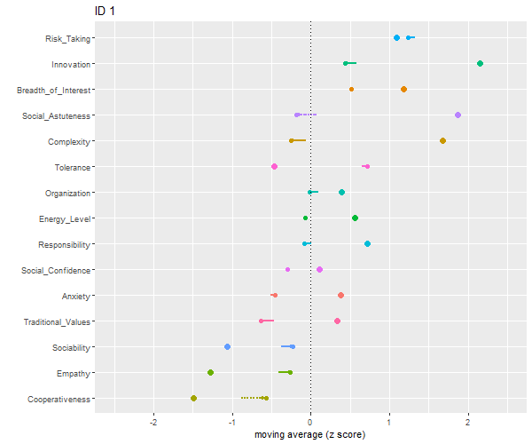

## CoP Personality Results (2 of 2)

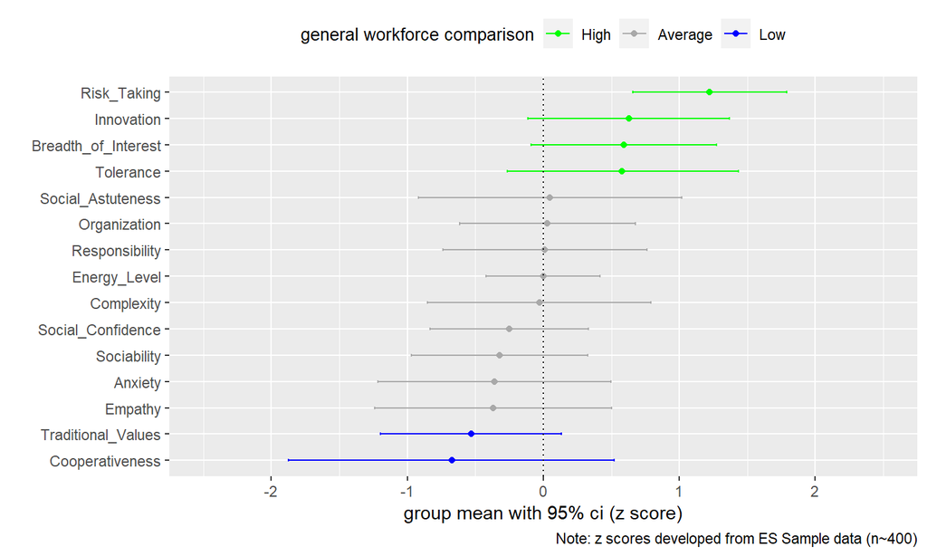

## CoP Analysis

### Hierarchical Clustering Dendrogram

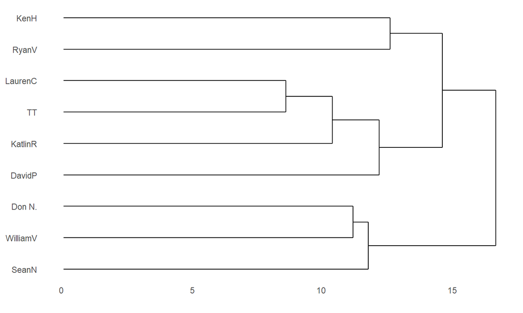

## Value Modeling (2 of 3)

8 of 15 traits were chosen to determine social science “fit”; experts rated importance of personality traits using AHP.

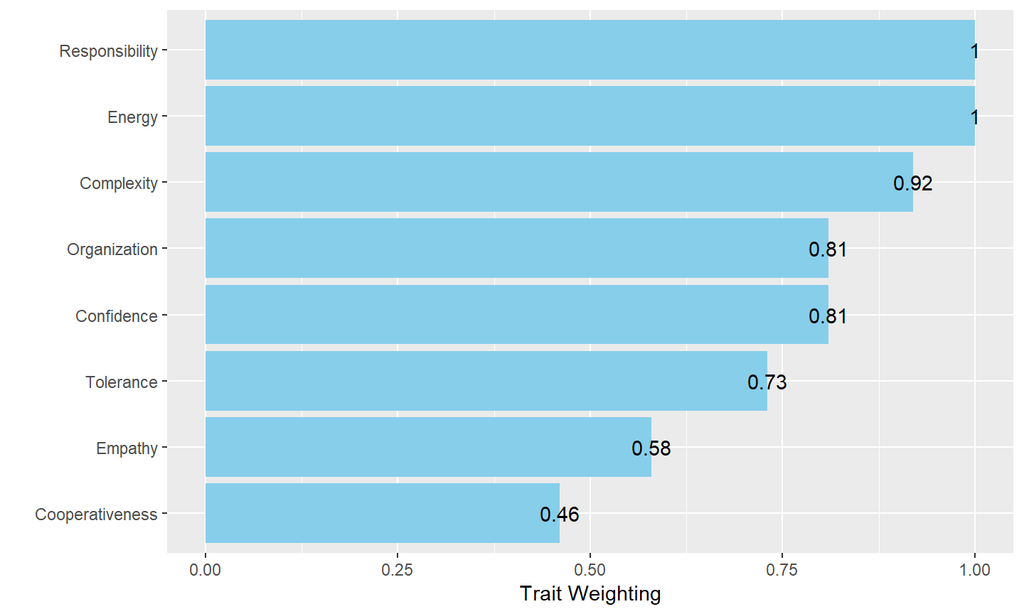

## Results (1 of 2)

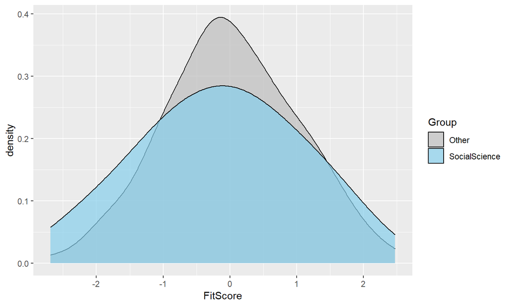

## Results (2 of 2)

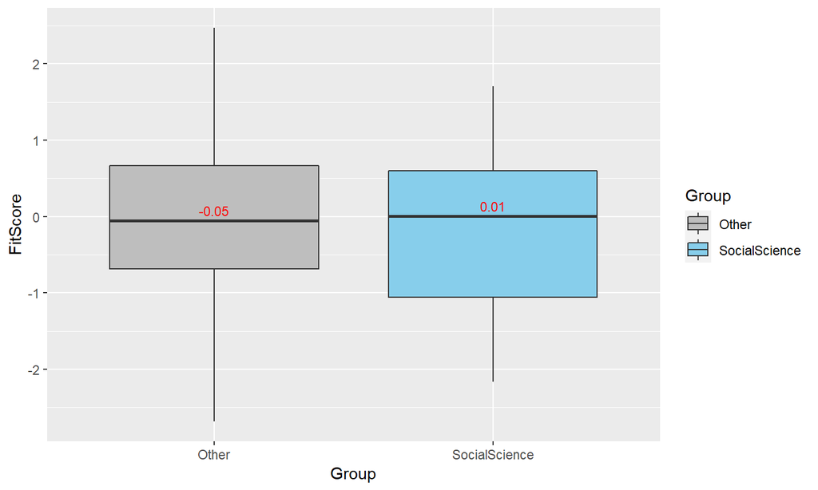

## Alternative Approach (Profile Analysis)

6 traits chosen to determine “fit.” These traits suggest a unique personality profile due to differences from the ES sample.

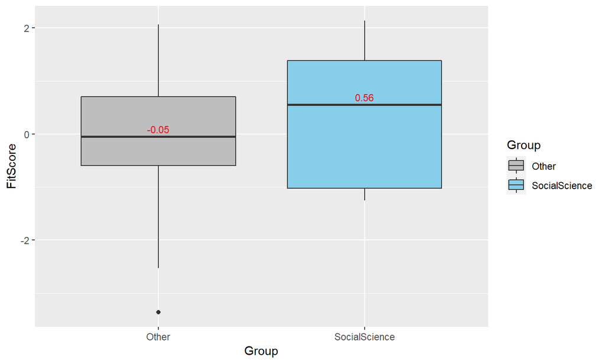

## Hobbies Word Cloud

[interactive chart not shown]

## Back-Up: Trait Descriptions (1 of 3)

Analytical

- Complexity: seeks intricate solutions to problems
- Breadth of Interest: interested in learning about a diversity of things
- Innovation: motivated to develop novel solutions to problems; values new ideas
- Tolerance: accepts people even though they may differ from oneself; welcomes dissent

## Back-Up: Trait Descriptions (2 of 3)

Emotional

- Empathy: tends to identify closely with other people and their problems
- Anxiety: tends to worry over inconsequential matters; apprehensive about the future
- Cooperativeness: is susceptible to social influence and group pressures; follows suit

Extroversion

- Sociability: eagerly join a variety of social groups; actively social
- Social Confidence: confident in dealing with others; shows presence in interpersonal situations
- Energy level: is active and spirited; does not tire easily; capable of intense work for long periods

## Back-Up: Trait Descriptions (3 of 3)

Opportunistic

- Social Astuteness: skillful at persuading others to achieve a particular goal; occasionally seen as manipulative of others, but ordinarily diplomatic
- Risk Taking: enjoys gambling and taking a chance; willingly exposes self to situations with uncertain outcomes

Dependable

- Organization: makes effective use of time; not easily distracted
- Traditional Values: values traditional customs and beliefs; others may view individual as “old-fashioned”
- Responsibility: strong obligation to be honest and upright; an inflexibly conscience